Concise Review: Patency of Small-Diameter Tissue-

Engineered Vascular Grafts: A Meta-Analysis of

Preclinical Trials

Ida Skovrind, Eva Bang Harvald, Helene Juul Belling, Christian Damsgaard

Jørgensen, Jes Sanddal Lindholt, Ditte Caroline Andersen

[figure not shown]

Concise Review: Patency of Small-Diameter

Tissue-Engineered Vascular Grafts:

A Meta-Analysis of Preclinical Trials

IDA SKOVRIND,<sup>a,c,</sup>*EVA BANG HARVALD,<sup>a,b,c,</sup>*HELENE JUUL BELLING,<sup>a,c</sup>

CHRISTIAN DAMSGAARD JØRGENSEN,<sup>e</sup>JES SANDDAL LINDHOLT,<sup>f</sup>DITTE CAROLINE ANDERSEN

a,b,c,d

Key Words.

Revascularization • Bypass • Tissue-engineered vascular grafts • Patency •

Meta-analysis

ABSTRACT

Several patient groups undergoing small-diameter (<6 mm) vessel bypass surgery have limited autol-

ogous vessels for use as grafts. Tissue-engineered vascular grafts (TEVG) have been suggested as an

alternative, but the ideal TEVG remains to be generated, and a systematic overview and meta-

analysis of clinically relevant studies is lacking. We systematically searched PubMed and Embase

databases for (pre)clinical trials and identiﬁed three clinical and 68 preclinical trials ([>rabbit];

873 TEVGs) meeting the inclusion criteria. Preclinical trials represented low to medium risk of bias,

and binary logistic regression revealed that patency was signiﬁcantly affected by recellularization,

TEVG length, TEVG diameter, surface modiﬁcation, and preconditioning. In contrast, scaffold types

were less important. The patency was 63.5%, 89%, and 100% for TEVGs with a median diameter

of 3 mm, 4 mm, and 5 mm, respectively. In the group of recellularized TEVGs, patency was not

improved by using smooth muscle cells in addition to endothelial cells nor affected by the endothe-

lial origin, but seems to beneﬁt from a long-term (46–240 hours) recellularization time. Finally, data

showed that median TEVG length (5 cm) and median follow-up (56 days) used in preclinical settings

are relatively inadequate for direct clinical translation. In conclusion, our data imply that future stud-

ies should consider a TEVG design that at least includes endothelial recellularization and bioreactor

preconditioning, and we suggest that more standard guidelines for testing and reporting TEVGs in

large animals should be considered to enable interstudy comparisons and favor a robust and

reproducible outcome as well as clinical translation. STEM CELLS TRANSLATIONAL MEDICINE

2019;8:671–680

SIGNIFICANCE STATEMENT

Small-diameter blood vessel bypass surgery is primarily performed using autologous arteries or

veins, yet several patient groups have limited grafts, and therefore substantial effort is put into

bioengineering small diameter tissue-engineered vascular grafts (TEVGs). This study provides the

ﬁrst-ever systematical status of TEVGs and has performed a meta-analysis of factors contributing

to TEVG patency in clinically relevant settings such as large animals. Thus, in an unbiased fash-

ion, this study determines critical parameters for in vivo patency of bioengineered TEVGs, and

also pinpoints the need for more standard guidelines for testing and reporting TEVGs in large

animals. The data will thus bring the ﬁeld a novel unbiased status that hopefully will accelerate

clinical translation of tissue engineered grafts in the near future.

INTRODUCTION

Reperfusing

ischemic

tissue

may

be

performed by endovascular or bypass surgery. As

such, coronary artery bypass grafting includes

connecting the internal mammarial artery to the

coronary artery distally for the occluded coronary

vessel or, alternatively, insertion of an autologous

vein or artery from ascending aorta to this coro-

nary segment. Similarly, in relation to peripheral

artery disease, autologous veins are used to redi-

rect blood around the affected vessel in the legs.

However, wound infection in the graft donor site

is a frequent complication, and former use of the

patient’s veins for bypasses, dialysis, varicose dis-

ease with or without removal of the saphenous

veins, as well as patients with hypoplastic v.

saphena magna or damages from previous throm-

bophlebitis have limited graft material. Synthetic

grafts such as Dacron and Teﬂon, which have

aLaboratory of Molecular

and Cellular Cardiology,

Department of Clinical

Biochemistry and

Pharmacology, Odense

University Hospital, Odense

C, Denmark; <sup>b</sup>Center for

Vascular Regeneration,

Odense University Hospital,

Odense C, Denmark;

cDepartment of

Cardiovascular and Renal

Research, University of

Southern Denmark, Odense

C, Denmark; <sup>d</sup>Clinical

Institute, University of

Southern Denmark, Odense

C, Denmark; <sup>e</sup>Department

of Mathematics and

Computer Science,

University of Southern

Denmark, Odense M,

Denmark; <sup>f</sup>Department of

Cardiac, Thoracic, and

Vascular Surgery, Odense

University Hospital, Odense

C, Denmark

*Contributed equally.

Correspondence: Ditte Caroline

Andersen, Ph.D., Odense

University Hospital/University

of Southern Denmark,

Winsloewparken 21, 3rd Floor,

5000 Odense C, Denmark.

Telephone: 65503975; e-mail:

dandersen@health.sdu.dk

Received December 12, 2018;

accepted for publication March

4, 2019; ﬁrst published March

28, 2019.

http://dx.doi.org/

10.1002/sctm.18-0287

This is an open access article

under the terms of the Creative

Commons Attribution-

NonCommercial-NoDerivs

License, which permits use and

distribution in any medium,

provided the original work is

properly cited, the use is non-

commercial and no modiﬁca-

tions or adaptations are made.

STEM CELLS TRANSLATIONAL MEDICINE 2019;8:671–680 www.StemCellsTM.com

© 2019 The Authors.

STEM CELLS TRANSLATIONAL MEDICINE published by Wiley Periodicals, Inc. on behalf of AlphaMed Press

[figure not shown]

TISSUE ENGINEERING AND REGENERATIVE MEDICINE

been used since 1950s, works relatively well for vascular grafts

with a large diameter; however, the success for small-diameter

synthetic vessels (<6 mm) is lacking [1]. The blood ﬂow in

smaller vascular grafts, higher thrombogenecity of the graft

material as well as poor homogeneity in the compliance of the

native vessel and the graft are all factors contributing to the

low patency of synthetic grafts with a diameter ≤6 mm [1–6].

Likewise, the use of allografts as an alternative remains com-

plicated and often gives rise to immune responses. Thus, novel

sources of blood vessels are highly demanded for bypass sur-

gery in various pathological states.

Already in 1986, Weinberg and Bell succeeded in bioengineer-

ing a multilayered artery with physiological properties resembling

that of a native vessel [7]. Although having low burst strength, this

work kick-started the ﬁeld of tissue-engineered vascular grafts

(TEVG), providing an alternative source for small-diameter blood

vessel grafts in bypass surgery. Yet, clinical translation of small-

diameter TEVG (from now on referred to as TEVG) is still restricted

to a few studies [8–10], and the ideal TEVG with long-term patency

remains to be developed. As summarized and discussed in many

excellent reviews [1, 11–13], multiple approaches are used to gen-

erate TEVGs from autologous cells grown on synthetic or biological

scaffolds with or without modiﬁcations, but also acellular conduits

have been rigorously tested. But how far are researchers indeed

from generating TEVG products that at least meet the 60%

patency obtained after 10 years in humans when using autolo-

gous grafts [14], and which approaches contribute positively to

the long-term patency of TEVGs?

Herein, we set out to combine systematic literature searches,

risk of bias assessments, and meta-analysis of selected parame-

ters to provide a status on TEVG in clinically relevant settings

such as large animals. With this we provide, to the best of our

knowledge, the ﬁrst meta-data on multiple factors inﬂuencing

TEVG patency as well as considerations on how to proceed with

generating the ideal TEVG.

MATERIALS AND METHODS

Search Strategy

The systematic literature search and design was performed in

agreement with the Preferred Reporting Items for Systematic

Reviews and Meta-Analyses guidelines [15]. One person (I.S.)

well-trained in the literature search performed the searches and

initial screening in the electronic databases PubMed and Embase

from inception to January 1, 2018. The search strategy was based

on the three key terms “tissue engineering,” “vascular grafts,”

and “in vivo evaluation,” and was composed of both indexed sub-

ject headings (MeSH and Emtree terms in PubMed and Embase,

respectively) as well as related free text terms. No database

limits were imposed on the search in PubMed, whereas in

Embase only the publication type “Article” was chosen for fur-

ther processing. All retrieved items were imported to EndNote

and duplicates were removed before further processing. The

complete search strategy can be found in Supporting Information

Figure S1.

Study Selection

Retrieved studies were screened against the inclusion criteria

using the systematic data management program Covidence

[16], ﬁrst based on title and abstract (I.S.), and secondly by a

full-text screening (independently by I.S. and H.J.B.). Overall,

inclusion criteria (Fig. 1 and Supporting Information Fig. S2)

embraced studies on tissue engineering of tubular small diame-

ter (≤6 mm inner diameter assessed before implantation) [1, 17,

18] blood vessels and their evaluation as interposition grafts in

large animals (>rabbit). The small-diameter criterion was met if:

the inner diameter was disclosed and was ≤6 mm; the inner

diameter could be inferred from pictures to be ≤6 mm; or the

study deﬁned small diameter as no more than ≤6 mm and

claimed to deal with small-diameter grafts. If information regard-

ing analyzed parameters such as follow-up time, patency, or distri-

bution of individuals among experimental groups were absent or

unclear to us, the study authors (only for studies <20 years) were

contacted for clariﬁcation. If information remained insufﬁcient

or still lacking, the study was excluded. Two studies could be

partly included despite insufﬁcient information and/or no author

response [19, 20]. Nine studies were completely excluded

(Supporting Information Fig. S3). Only primary studies published

in peer-reviewed journals in English language were eligible;

others were excluded (Supporting Information Fig. S4).

Data Extraction

All data were extracted independently by I.S. and H.J.B., and then

repeated independently by I.S. and E.B.H. Any disagreements were

solved by discussion between the disagreeing parties and by

involving D.C.A. to solve the controversy. For each graft, data were

extracted (see Supporting Information datasheet) on animal

model, graft diameter (mm), follow-up (days [1 month = 30 days,

1 year = 365 days]), the addition of surface modiﬁcation (conju-

gated molecules, Supporting Information Fig. S5), recellularization

(cellular/acellular), preconditioning (yes/no), length (cm), publica-

tion year, the scaffold type (natural, synthetic, hybrid [of natural

and synthetic], self-assembly cellular sheet, decellularized, in-body

tissue architecture, and combinations of these; Supporting Infor-

mation Fig. S6), and primary patency at the ﬁnal evaluation time

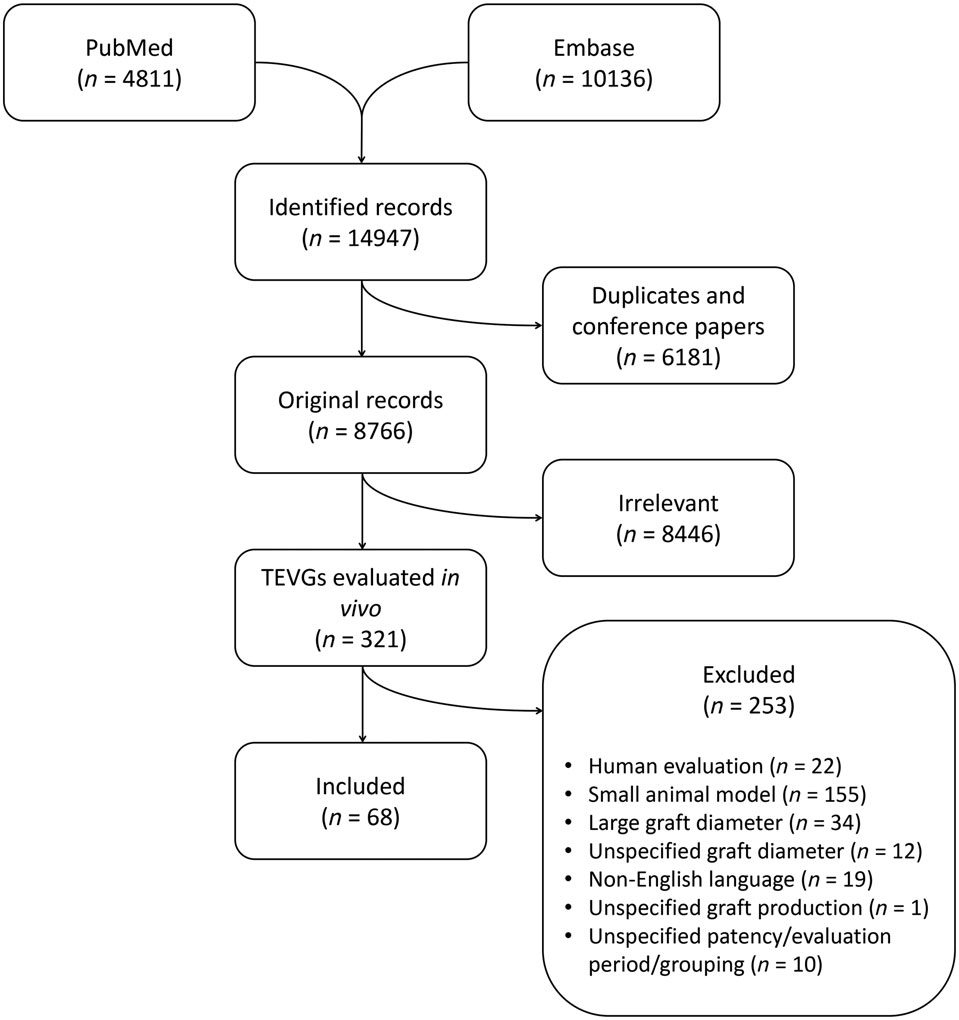

Figure 1.

Flowchart of the literature search and exclusion criteria

for meta-analysis. See Materials and Methods for details.

© 2019 The Authors. STEM CELLS TRANSLATIONAL MEDICINE published by

Wiley Periodicals, Inc. on behalf of AlphaMed Press

STEM CELLS TRANSLATIONAL MEDICINE

672

TEVG Patency: A Meta-Analysis

point. A patent vessel is deﬁned as an open vessel (any degree of

partial obstruction is still deﬁned as patent as in general for the

ﬁeld). A second and a third round of data extraction were per-

formed independently by E.B.H. and D.C.A. to retrieve information

on type of circulation (artery, venous, arterio-venous), anti-

thrombotic treatment (type and duration), mechanical prop-

erties (methods used and strength; Supporting Information

Fig. S7), cell type according to origin (blood, vessel, bone mar-

row, and whether cells were endothelial or smooth muscle

cells and of progenitor/stem cell (blood, bone marrow, other)

or mature/differentiated (vessel) origin as well as details on

cell culturing (media and culture time) and recellularization

time (Supporting Information Fig. S8). Again, any disagree-

ments were rechecked and solved. Information on the patency

of the grafts corresponding to each study is represented in

two ways: the patency for each study group in percentage

(of patent grafts in the group) as reported by the authors of

the study; and each graft separately, patency indicated as

either patent or occluded (i.e., binary). The latter indication of

patency was used for the regression analysis, as it considers

the number of grafts in the study groups.

Quality Assessment

All studies were evaluated for risk of bias using a customized

tool (Supporting Information Fig. S9), which was developed

based on the recommendations of the Agency for Healthcare

Research and Quality [21]. Using this tool, both study design,

execution and reporting are assessed in a total of 10 catego-

ries, including the animal model chosen for in vivo evaluation

(dog < sheep, goat, pig < nonhuman primate; i.e., the more

similar to human physiology, the better); whether the length

of the implanted graft was stated (not reported < reported as

interval or approximation < reported as exact measurement);

the choice of control (use of control in another incomparable

individual and location or no control < use of control in the

same location but in another comparable individual < use of

control in the same individual and equivalent contralateral loca-

tion); the consistency of treatment (highly inconsistent treatment

and/or outcome assessment within or between groups < slight

differences in treatment and/or outcome assessment within or

between groups of little or no consequence < consistent treat-

ment and outcome assessment within and between groups); the

length of the evaluation period (divided into three intervals based

on previous observations of pathophysiological events occurring in

the graft post implantation [20] and subsequent expected time

graft failure [13]: [<1 month] < [1–9 months] < [>9 months]); the

method for validation of the graft patency (another method than

angiography and ultrasonography < either angiography or ultraso-

nography < both angiography and ultrasonography), and whether

the graft quality was evaluated by other methods including

mechanical and histological evaluation (no assessment of grafting

success besides patency < assessment of one parameter of grafting

success besides patency < assessment of at least two parameters

of grafting success besides patency); the incident of unexpected

events or treatments and whether such may affect the outcome of

the study (unintended or concurrent interventions that can heavily

inﬂuence results < unintended or concurrent interventions that

might slightly inﬂuence results, or that are accounted for in the

results < no unintended or concurrent interventions); the existence

of drop-outs of the study and whether such was included

(if possible) in the overall evaluation (loss of participants,

without inclusion of drop-out data in the synthesis of results <

loss of participants with partial inclusion of drop-out data in the syn-

thesis of results < no loss of participants, or loss of participants with

inclusion of drop-out data in the synthesis of results); and ﬁnally,

whether the authors reported any conﬂict of interest (no reported <

present < absent). The studies were rated independently (I.S. and

E.B.H.) in each category as low risk, medium risk, or high risk of bias,

with a corresponding score of low (1), medium (2), or high (3) risk of

bias, respectively. The results are visualized by a heatmap using the

Euclidean distance measure to compute the distances. The order of

the risk of bias categories is according to total sum with the

highest scoring. The difference in patency between the group of

studies scoring low, medium, or high risk of bias was tested using

Dunn’s test of multiple comparison (with p-values adjusted using

the Benjamini–Hochberg method [22]) following Kruskal–Wallis

tests for each parameter, and the patency distribution was plotted

as a box-and-whiskers plot. The patency was here deﬁned as the

reported percentage for each group comprising the studies and

tested against high risk of bias.

Regression and Exploratory Data Analysis

A binary logistic regression model was ﬁtted using patency

(patent and occluded coded numerically as 1 and 0, respec-

tively) as the dependent variable. For the regression analysis,

we treated variables that can be used as interventions in the

graft production in a sensible manner as candidate explana-

tory variables: length (continuous), diameter (continuous),

recellularization (binary), scaffold type (categorical), surface

modiﬁcation (binary), and preconditioning (binary). For further

details of each of these explanatory variables, see above. For

model selection, (a) backward elimination, (b) forward selec-

tion, (c) bidirectional elimination, and (d) exhaustive searches

for the best subsets of explanatory variables was performed

using the Akaike information criterion and the Bayesian infor-

mation criterion, respectively. Remarkably, these approaches

to model selection all suggested the same subset of explana-

tory variables, supporting the ﬁnal choice of model: length,

diameter, recellularization, surface modiﬁcation, and pre-

conditioning. Prior to ﬁtting the model, listwise deletion was

used to eliminate 142 observations with missing values, since

we assume that the probability of missing data on length or

diameter does not depend on the values of any of the explan-

atory variables. Notably, since the proposed regression model

is logistic, listwise deletion yields consistent estimates of the

regression coefﬁcients and their standard errors, even if the

probability of missing data on length or diameter depends on

the value of patency [23]. The proposed ﬁnal model assuming

a binomial distribution of the dependent variable was com-

pared with the quasi-binomial model estimating an additional

dispersion parameter (Supporting Information Fig. S10) to con-

ﬁrm that the standard errors were similar.

As an exploratory analysis, a Pearson’s chi-squared test

with Yates’ continuity correction was used to test the null

hypothesis that the patency/occlusion of a graft is indepen-

dent of recellularization. Similarly, a Pearson’s chi-squared test

with Yates’ continuity correction was used to test the null

hypothesis that the patency/occlusion of a graft is indepen-

dent of cell type. Likewise, for diameter (pooled in three bins,

[2 mm, 4 mm), [4 mm, 5 mm), and [5 mm, 6 mm]), scaffold

type, and type of conjugated molecule, a Pearson’s chi-squared

test with Yates’ continuity correction was performed, and in

www.StemCellsTM.com

© 2019 The Authors. STEM CELLS TRANSLATIONAL MEDICINE published by

Wiley Periodicals, Inc. on behalf of AlphaMed Press

Skovrind, Harvald, Juul Belling et al.

673

case the overall chi-squared test was signiﬁcant, it was followed

by a post hoc analysis using Fisher’s exact test with Benjamini–

Hochberg adjusted p-values for testing signiﬁcance of differ-

ences among all pairs. For duration of recellularization, the data

was pooled in two bins, short-term (0.16–6 hours) and long-

term (46–240 hours), and Pearson’s chi-squared test with Yates’

continuity correction was performed. For testing the effect of anti-

coagulation factors on patency, the Wilcoxon rank sum test was

used on the reported patency (in percentage) for each group of

grafts composing the study. For mechanical testing, the reported

strength for each of the three most frequently used methods was

plotted against the reported patency (in percentage) for each

study. The term “signiﬁcant” refers to statistical signiﬁcance at the

.05 level, unless otherwise stated. For all statistical analyses the R

software version 3.3.3 was used [24].

RESULTS

Included Studies and Study Characteristics

A total of 14,947 studies were retrieved from the two data-

bases PubMed and Embase (Fig. 1 and Supporting Information

Fig. S1). Exclusion of duplicates and then systematic screening

of title and abstract using the Covidence platform revealed

321 studies, which was ﬁnally limited by thorough text reading

to 68 studies based on inclusion criteria [19, 25–91]. These

studies represented a total of 873 grafts: 258 occluded and

615 patent grafts at the end of the evaluation period. An unam-

biguous description of parameters, including animal model,

scaffold type, cell treatment, scaffold surface modiﬁcations,

graft diameter and length, evaluation period, and patency, are

listed for each study in Supporting Information Figure 11. These

speciﬁc parameters reﬂect main variables suggested and dis-

cussed in the ﬁeld to affect in vivo patency of small-diameter

bioengineered blood vessels [1, 13]. Approximately half of the

studies were published in the last decade, and 59 of the 68 stud-

ies contained several experimental groups of grafts. Nine differ-

ent types of scaffolds were used (Supporting Information Fig. S6)

and the ratios of acellular versus cellular TEVGs ranges from 0.28

to 1 between those scaffold types (data not shown). Six different

animal species were used in the 68 studies, yet since animal

model does not qualify as a parameter for clinical translation, we

did not include it in the regression model, but maintained it as a

parameter for study quality assessment (i.e., similarity to human

physiology). Ninety percentage of TEVGs were tested in an artery

circuit, whereas only 9% and 1% were tested in arterio-venous

and venous circuits, respectively. Thirty-seven studies used

antithrombotic treatment, but overall patency (100; 77.1; 33.7

[median; mean; SE]) remained nonsigniﬁcant (p = .3978) from

studies not using this treatment (100; 74.5; 37.9 [median;

mean; SE]). The median graft diameter of all TEVGs was 4 mm

and ranged from 2 to 6 mm. When divided into three logical

diameter bins to obtain sufﬁcient number of studies and grafts

in each bin, the median patency was 63.5%, 89%, and 100% for

TEVGs with a median diameter of 3 mm, 4 mm, and 5 mm,

respectively (Supporting Information Fig. S12). The median

graft length was 5 cm and ranged from 1 to 25 cm, where the

length of 510 of 873 analyzed TEVGs exceeds the diameter by

a factor 10, as recommended by others to obtain a reliable

patency measure [13]. The median of follow-up was 56 days,

and ranged from many short-term studies lasting 1 month or

less (370 grafts) to longer, more clinically relevant [20] studies

evaluated for >6 months (136 grafts). Most grafts, however, were

evaluated in the time frame 1 day to 6 months (736 grafts). The

median TEVG patency was 83% (n = 873) for a median follow-up

time of 56 days (95% conﬁdence interval: [42, 60]).

Study Quality

To evaluate the presence of bias, we established our own risk of

bias assessment tool (Supporting Information Fig. S9) according

to what has been recommended by others [21]. We scored stud-

ies according to three categories: high risk of bias (equal to 3),

medium risk of bias (equal to 2), and low risk of bias (equal to 1).

Accumulation of the total score for each study is not rec-

ommended since rating of individual categories is inappropriate

[21]. Yet, by summing scores across studies and determining the

median score for each category (Fig. 2A), we found that only

conﬂicting interests were prone to high bias (median: 3). In con-

trast, animal model (relevance to human), follow-up (relevance

to clinical scenario), patency assessment, cointerventions (e.g.,

antithrombotic treatment and treatment of unexpected compli-

cation during or after surgery), controls (proper controls), con-

sistency, and graft length were mostly affected by medium bias

across studies (median: 2), whereas drop-out and secondary

methods (use of supportive methods) were at a low risk of bias

(median: 1; Fig. 2A).

We determined whether patency was different between

low, medium and high risk of bias groups within each category

using Dunn’s test of multiple comparison following Kruskal–

Wallis tests. These data revealed that a higher risk of bias

results in an improved patency for only patency assessment and

the use of appropriate control, whereas no evidence of associa-

tion was found for other risk of bias categories (Fig. 2B).

Meta-Analysis of Extracted Data

In order to assess the effects of explanatory variables on the

patency of the graft, we ﬁtted a binary logistic regression model

using patency (patent and occluded coded numerically as 1 and

0, respectively) as the dependent variable (Fig. 3A, 3B). For the

regression analysis, we initially used the candidate explanatory var-

iables: length, diameter, recellularization, scaffold type, surface

modiﬁcation, and preconditioning. Yet, for none of the scaffold

types (Supporting Information Fig. S6), the coefﬁcients were statis-

tically signiﬁcantly different from the coefﬁcient of the reference

type (decellularized; .17 < p < .92). Moreover, a likelihood ratio

test (data not shown) suggested that the variable scaffold type did

not signiﬁcantly improve the model ﬁt. This suggests that the scaf-

fold types (Supporting Information Fig. S6) investigated in the

68 studies are very similar in functionality and difﬁcult to distin-

guish in terms of resulting patency. Consequently, scaffold type as

a variable did not enter into the ﬁnal model.

In contrast, the proposed ﬁnal model (Fig. 3C) showed that

graft length had a highly statistically signiﬁcant (p < .001) negative

effect on graft patency (Fig. 3D, 3E). Similarly, graft diameter had a

highly statistically signiﬁcant (p < .001) positive effect on graft

patency (Fig. 3D, 3E), a result that was expected and in agreement

with the general knowledge in the ﬁeld that small diameter vessels

are more prone to being occluded but here veriﬁed at a meta-

analysis level. Remarkably, according to our model, recellularization

(p = .0076), surface modiﬁcation with conjugated molecules

(p = .0034), and preconditioning (p = .0046) also appear to have

statistically signiﬁcant positive effects on graft patency (Fig. 3D, 3E).

© 2019 The Authors. STEM CELLS TRANSLATIONAL MEDICINE published by

Wiley Periodicals, Inc. on behalf of AlphaMed Press

STEM CELLS TRANSLATIONAL MEDICINE

674

TEVG Patency: A Meta-Analysis

Exploratory Data Analysis of Meta-Data

To analyze the variables with an impact on graft patency in detail,

we performed exploratory analyses. Yet, since the results for graft

surface modiﬁcations with conjugated molecules (Supporting Infor-

mation Fig. S5) and graft preconditioning, derived from a relative

low number of studies that each embraces various approaches for

these two variables, respectively, we speculated that further explor-

atory analysis would be inadequate currently. Instead, we chose to

analyze in detail the impact of graft length and recellularization as

well as the cell type and origin of the recellularized cells used on

graft patency.

Recellularized TEVGs accounted for 309 (73 TEVG groups/30

studies) of the 873 TEVGs analyzed. As compared with acellular

TEVGs, recellularized grafts were more prone to being patent

(χ<sup>2</sup>= 48.333, df = 1, p < .001; Fig. 3F). In the group of recellularized

with endothelial cells on the inside and smooth muscle cells on the

outside. Interestingly, our data showed that TEVGs with endothelial

cells alone exhibited a patency that was not statistically signiﬁcantly

different (χ<sup>2</sup>= 1.5747, df = 1, p = .2095) from the patency in the

group with both endothelial and smooth muscle cells (Fig. 3G).

Furthermore, extracting meta-data on the origin of used endothe-

lial cells, we found TEVGs to be seeded with endothelial cells

derived from large blood vessel (162 TEVGs), peripheral blood

(111 TEVGs), bone marrow (13 TEVGs) and other organs such

as fat (14 TEVGs). Yet, no statistically signiﬁcant difference

(χ<sup>2</sup>= 3.0996, p = .4093) was revealed in patency between TEVGs

with endothelial cells of different origins (Fig. 3H). Similar results

were obtained for smooth muscle cells (data not shown). Also, we

found no evidence of any association (χ<sup>2</sup>= 0, p = 1; without con-

tinuity correction, p = .9666) between patency and the stem

cell/progenitor state of the endothelial origin (data not shown).

Noteworthy, the median recellularization time was 2 hours for

patent TEVGs (Supporting Information Fig. 8), but when

recellularization time was divided into two natural bins: short-

term (0.16–6 hours) and long-term (46–240 hours), we found that

long-term recellularization was better (χ<sup>2</sup>= 8.3105, p = .0040) in

terms of a higher fraction of patent TEVGs (Fig. 3J).

The ﬁnal model suggests that graft length has a negative

effect on graft patency, whereas diameter has a positive effect

on graft patency (Fig. 3D, 3E). This is important, since it has

been suggested that the TEVG length should exceed the diam-

eter by a factor of 10 to avoid false positive patency [13].

However, we found that grafts not meeting this criterion were

patent (Fig. 3I). In this regard, it is also worth noting that the

length, the diameter, or both were not reported for 142 TEVGs.

Finally, the 68 studies used nine different approaches to test

mechanical properties of the TEVGs (Supporting Information Fig. S7),

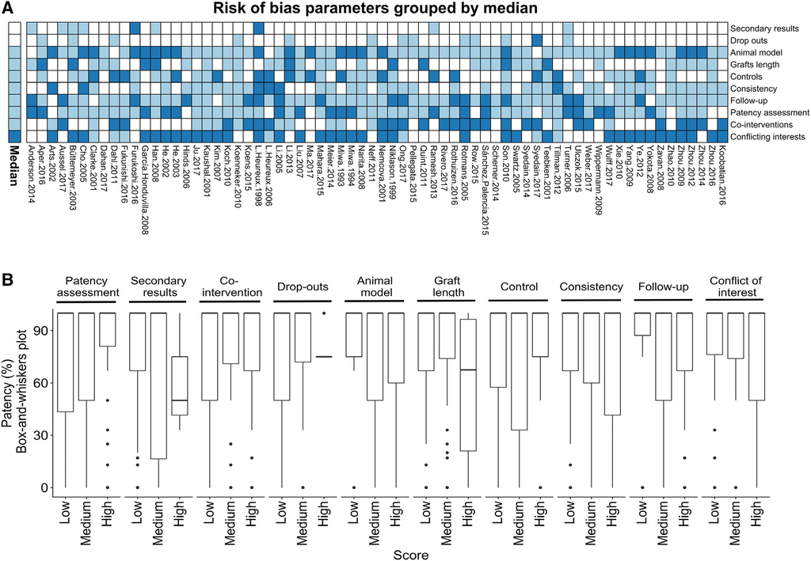

Figure 2.

Risk of bias (RoB) analysis. (A): Heatmap of RoB for all included studies. White, light blue, and dark blue indicates low, medium,

and high RoB, respectively. The annotation bar to the left indicates the median for each RoB category. The order of the rows (RoB catego-

ries) denotes the median for each category, low to high from the top. (B): Boxplots (box-and-whiskers, i.e., the median, hinges, whiskers,

and outliers) of patency distribution among RoB categories for each score (low, medium, or high). Dunn’s test of multiple comparison was

used to test low and medium groups against high RoB, to identify RoB categories associated with high patency as indicated by p-value.

www.StemCellsTM.com

© 2019 The Authors. STEM CELLS TRANSLATIONAL MEDICINE published by

Wiley Periodicals, Inc. on behalf of AlphaMed Press

Skovrind, Harvald, Juul Belling et al.

675

a key speciﬁcation of the TEVG strength and another valuable

read for the TEVG quality in addition to in vivo patency. Based

on a correlation analysis, we found that burst pressure and

suture retention tests, which were the two most commonly used

methods, expectably correlated (r = .48, p < .001 and r = .31,

p = .0015, respectively) with in vivo patency (Supporting Infor-

mation Fig. S7).

DISCUSSION

To the best of our knowledge, we here provide the ﬁrst-ever

meta-analysis showing that recellularization, surface modiﬁca-

tion, and preconditioning all improve TEVG patency in a clinically

relevant setting. The observed median patency of 83% was rela-

tively high, but we also identiﬁed that many of the preclinical

studies, even though performed in large animals, uses TEVG

lengths (median: 5 cm) and follow-up (median: 56 days) that are

inadequate for clinical use and thus cannot be directly compared

with the 10-year 60% patency known for autologous grafts.

As discussed in several reviews [1, 11–13] and as reﬂected

systematically in our study, various approaches have been used

to generate TEVGs. Still, the ﬁeld is in its infancy with reference

to the few clinical translations [8–10], which were identiﬁed by

our search strategy. Therefore, we consider the heterogeneity

of TEVG studies as an advantage, since tremendous progress

emerges every day for scaffold preparation and bioreactor

developments, which likely will beneﬁt the ﬁeld. Yet, the large

heterogeneity of approaches used also complicates progress

evaluation, where to continue, and what approaches to elimi-

nate. Since our results are based on an unbiased systematical

approach reﬂecting the ﬁeld’s status and not only a single study,

they may be used to accelerate such decisions.

Speciﬁcally, we found that acellular TEVGs as compared

with recellularized grafts were less prone to being patent

(62.4% versus 85.1%, respectively), supporting for the ﬁrst-

time previous studies [47, 62, 92, 93] on a meta-analysis level.

Moreover, our analysis pinpoints that the use of smooth mus-

cle cells in addition to endothelial cells do not provide an

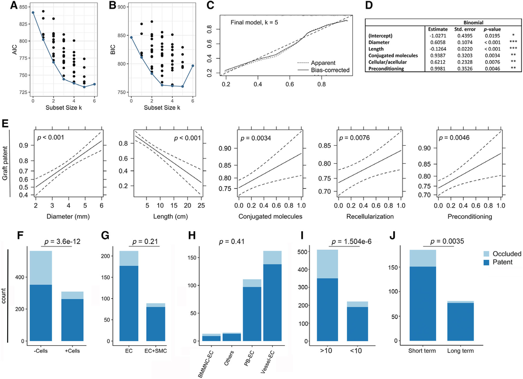

Figure 3.

Binary logistic regression and exploratory data analysis. (A, B): The Akaike information criterion and the Bayesian information

criterion for each of the 64 potential models are plotted according to number of explanatory variables (k). The “best” model for each sub-

linear structure of the model while allowing for interpretation on a familiar scale, the effects are plotted on the scale of the linear predic-

tor of explanatory variables, whereas the vertical axis is labeled on the scale of the dependent variable (i.e., the probability scale). Dotted

lines indicate standard error. Association between patency at the time of follow-up and (F) recellularization of the graft, (G) endothelial

cells only, or endothelial cells and smooth muscle cells in combination seeded on the graft, (H) endothelial cell origin, (I) the

length/diameter ratio, and (J) the duration of recellularization. The indicated p-values computed by Monte Carlo simulation are from

Pearson’s chi-squared test.

© 2019 The Authors. STEM CELLS TRANSLATIONAL MEDICINE published by

Wiley Periodicals, Inc. on behalf of AlphaMed Press

STEM CELLS TRANSLATIONAL MEDICINE

676

TEVG Patency: A Meta-Analysis

immediate beneﬁt to the patency. Thus, future studies may

focus more speciﬁcally on generating TEVGs with endothelial

cells alone, and here improve the speciﬁc condition for achiev-

ing a mature continuous sheet of fully functioning endothelial

cells. Based on our data, preconditioning in emerging bioreac-

tors will likely enhance this process, and it will be interesting

in the future to do speciﬁc exploratory meta-analysis of this

parameter, when more studies exploiting this approach have

been performed. Yet, our data do suggest that long-term (sev-

eral days) recellularization time prior to in vivo analysis is ben-

eﬁcial, but it is appropriate to speculate that recellularization

duration may be reduced with the use of preconditioning bio-

reactors. In contrast, the physiological source of the endothe-

lial cell does not seem to have a major impact on the patency

according to our analysis. Thus, easy accessibility and clinically

relevant cell numbers for generating TEVGs of 20–60 cm seem

more important in relation to clinical translation of the approach

than the origin for endothelial cell function itself. However, it is

important to emphasize that we did not distinguish between the

methods used for obtaining the cells. It is thus likely that some

endothelial cell preparations are purer than others, and therefore

result in a better fully functioning endothelium. We also did not

distinguish between autologous, allogenic, and xenogenic cell

preparations, which may elicit different host immune responses

and hereby impact patency. Yet, we did speculate that an imma-

ture origin using circulating-derived or bone marrow-derived

endothelial progenitors could be more beneﬁcial for the patency

than using mature blood vessel derived endothelial cells, but

did not ﬁnd a relationship. Systemic antithrombotic treatment

was not included in the meta-analysis as an explanatory variable

but included as part of cointerventions in the risk of bias analy-

sis, since it is a standard treatment for humans undergoing

impact on patency as otherwise could have been expected. Yet,

antithrombotic modiﬁcations used for scaffold surface modiﬁca-

tions did turn out to have an immediate positive effect on TEVG

patency in our analysis. However, we consider that the number

of studies using surface modiﬁcation still is too low to make any

robust conclusions and in addition embraces several types of

modiﬁcations. Overall, we did not observe that any of the scaf-

fold types were statistically signiﬁcantly different from the refer-

ence type (decellularized), and thus the type of scaffold used

may be less important. Yet, we can only speculate if another ref-

erence type would change the result, but we chose, prior to

analysis, decellularized vessel as the reference type since this

scaffold is closest to native vessels. Moreover, new scaffolds are

developed continuously, and we may in the ﬁeld not have iden-

tiﬁed the most optimal one yet.

Regarding follow-up time, we showed that the included

studies have a median of 56 days, which is clinically inadequate.

Importantly, this relative short follow-up does not generally

allow for hyperplasia induced occlusions to occur [94]. Thus, the

relative high patency reported in large animal studies might be

exaggerated, and whether this is comparable to the overall

patency of 60% obtained after 10 years in humans when using

autologous grafts remains questionable [14]. Indeed, we did not

observe an association between follow-up time and patency in

the timeframe used for animals (data not shown), yet again this

could be due to the short evaluation time of most studies.

Likewise, the median TEVG length in the animal studies was

5 cm, which seems irrelevant in relation to most clinical bypass pro-

cedures that often requires >20 cm. Most likely this reﬂects dif-

ferent anatomical targets in the animal settings for the TEVG

tested (of which we had no restrictions for inclusion in our analy-

sis). However, shorter grafts are suggested to be more prone to

being patent [34] and our study for the ﬁrst time adds meta-

analyses to support this statement. Thus, we can only speculate if

the relative high patency obtained for the short TEVGs in animal

trials can be recapitulated if the TEVG length is increased to clini-

cal dimensions. Thus, future studies addressing longer TEVGs will

be valuable. Moreover, careful reporting on the length and diame-

ter is also desired to enable robust comparisons of TEVG patency.

We encountered 12 studies with insufﬁcient reporting on length.

On a similar note, it is important to emphasize that the animals

used are normal, healthy individuals, whereas patients most often

suffer various vascular defects and diseases that may further lower

patency of TEVGs. One advantage of the large animal studies is,

however, the possibility for performing subsequent explant anal-

ysis of the in vivo tested TEVGs. We did not focus on those

results but found that the majority of studies (66) did perform

additional explant analysis, which clearly supports the robust-

ness of the corresponding in vivo patency measurements.

Another important analysis is in vitro mechanical testing that

at least for burst pressure and suture retention herein corre-

lates with in vivo patency. Thus, these mechanical testing

methods that are less complex and more easily performed

than large animal studies may further help researchers predict

which TEVGs that indeed will perform in vivo and thereby pre-

vent time consuming in vivo studies on low quality TEVGs. For

obvious ethical restrictions the follow-up in clinical studies are

based on the physiology of the patient (i.e., body weight), physi-

ological complications arising post implantation, and in vivo

patency assessed by for example, Doppler ultrasound. Thus, clini-

cal studies may be biased by secondary and undiagnosed effects,

which may result in a lower patency. Both ultrasound and palpa-

tion are generally considered subjective measures for in vivo

patency assessment, whereas angiography is more reliable [95,

96]. In the included animal studies, 32 of the studies used ultra-

sound alone, whereas nine studies used angiography or both.

Indeed, high risk of bias for patency assessment was encountered

to be associated with a higher patency. During our systematic

reviewing process, we identiﬁed that one major issue in the ﬁeld

might be that patency is reported as a binary measure. This elimi-

nates the possibility to distinguish partly occluded scaffolds, which

could be of beneﬁt for the ﬁeld, but at the moment is limited by

the available methods. Indeed, the secondary analysis performed

in large animal studies enables a more robust and detailed analy-

sis of graded patencies, which could support reported patency.

Finally, we cannot emphasize enough that the present analy-

sis is restricted to the data collected for the present study and to

the statistical evaluation methods chosen herein. In particular, we

cannot exclude that a few eligible studies have been unnoticed

by our search strategy, and we apologize to authors of those stud-

ies. Also, it is likely that other factors than those analyzed and dis-

cussed here have an impact on the patency. Such factors include

but are not limited to the addition of speciﬁc growth and differ-

entiation factors to culture medium, as well as under what condi-

tions cells are seeded and cultured, that is, single-perfusion or

bi-perfusion and static or 3D rotation, oxygen tensions, and so on.

www.StemCellsTM.com

© 2019 The Authors. STEM CELLS TRANSLATIONAL MEDICINE published by

Wiley Periodicals, Inc. on behalf of AlphaMed Press

Skovrind, Harvald, Juul Belling et al.

677

CONCLUSION

Thus, in conclusion our data underscore that recellularization

of the TEVG with endothelial cells inside the lumen for several

days is a prerequisite with the type of scaffolds considered

hereto and preconditioning and scaffold surface modiﬁcation

may further beneﬁt patency. Moreover, our data suggest that

more standard guidelines for testing and reporting TEVGs in

large animals should be considered at least with regards to

TEVG length, follow-up, patency assessment, and the use of

appropriate controls.

ACKNOWLEDGMENTS

We acknowledge all authors who provided further details on

published studies, enabling our analysis to be as optimal as possi-

ble. This study was partly supported by a strategic grant from

Odense University Hospital (OUH), research ﬁnance from Depart-

ment of Clinical Biochemistry and Pharmacology (OUH), and a

grant from the Danish Innovation Foundation (#7051-00001A).

AUTHOR CONTRIBUTIONS

I.S.: collection of data, data analysis and interpretation, manuscript

writing, ﬁnal approval of manuscript; H.J.B.: collection of data, data

analysis and interpretation, ﬁnal approval of manuscript; E.B.H.:

collection of data, data analysis including statistics, manuscript

writing and editing, ﬁnal approval of manuscript; C.D.J.: data analy-

sis including statistics, manuscript editing, ﬁnal approval of manu-

script; J.S.L.: data interpretation, manuscript writing and editing,

ﬁnal approval of manuscript; D.C.A.: conception and design, collec-

tion of data, data analysis and interpretation, manuscript writing,

ﬁnal approval of manuscript, ﬁnancial support.

DISCLOSURE OF POTENTIAL CONFLICTS OF INTEREST

The authors indicated no potential conﬂicts of interest.

DATA AVAILABILITY STATEMENT

The data that support the ﬁndings of this study are available

in the main article and in the supplemental material available

online or may be obtained from the corresponding author

upon reasonable request.

REFERENCES

1

Seifu DG, Purnama A, Mequanint K et al.

Small-diameter vascular tissue engineering. Nat

Rev Cardiol 2013;10:410–421.

2

Kannan RY, Salacinski HJ, Butler PE et al.

Current status of prosthetic bypass grafts: A

review. J Biomed Mater Res B Appl Biomater

2005;74:570–581.

3

McBane JE, Sharifpoor S, Labow RS et al.

Tissue engineering a small diameter vessel

substitute: Engineering constructs with select

biomaterials and cells. Curr Vasc Pharmacol

2012;10:347–360.

4

Hoenig MR, Campbell GR, Rolfe BE et al.

Tissue-engineered blood vessels: Alternative to

autologous grafts? Arterioscler Thromb Vasc

Biol 2005;25:1128–1134.

5

Baguneid M, de Mel A, Yildirimer L et al.

In vivo study of a model tissue-engineered

small-diameter vascular bypass graft. Bio-

technol Appl Biochem 2011;58:14–24.

6

Desai M, Seifalian AM, Hamilton G. Role

of prosthetic conduits in coronary artery

bypass grafting. Eur J Cardiothorac Surg 2011;

40:394–398.

7

Weinberg CB, Bell E. A blood vessel

model constructed from collagen and cultured

vascular cells. Science 1986;231:397–400.

8

Lawson JH, Glickman MH, Ilzecki M et al.

Bioengineered human acellular vessels for dial-

ysis access in patients with end-stage renal

disease: Two phase 2 single-arm trials. Lancet

2016;387:2026–2034.

9

Olausson M, Kuna VK, Travnikova G et al.

In vivo application of tissue-engineered veins

using autologous peripheral whole blood: A

proof of concept study. EBioMedicine 2014;1:

72–79.

10

Wystrychowski W, Cierpka L, Zagalski K

et al. Case study: First implantation of a frozen,

devitalized tissue-engineered vascular graft for

urgent hemodialysis access. J Vasc Access 2011;

12:67–70.

11

Cleary MA, Geiger E, Grady C et al.

Vascular tissue engineering: The next genera-

tion. Trends Mol Med 2012;18:394–404.

12

Song H-HG, Rumma RT, Ozaki CK et al.

Vascular tissue engineering: Progress, chal-

lenges, and clinical promise. Cell Stem Cell

2018;22:340–354.

13

Thomas LV, Lekshmi V, Nair PD. Tis-

sue engineered vascular grafts—Preclinical

aspects. Int J Cardiol 2013;167:1091–1100.

14

de Vries MR, Simons KH, Jukema JW

et al. Vein graft failure: From pathophysiology

to clinical outcomes. Nat Rev Cardiol 2016;

13:451–470.

15

Liberati A, Altman DG, Tetzlaff J et al.

The PRISMA statement for reporting systematic

reviews and meta-analyses of studies that eval-

uate health care interventions: Explanation and

elaboration. J Clin Epidemiol 2009;62:e1–e34.

16

Software Csr. Veritas Health Innovation.

17

Isenberg BC, Williams C, Tranquillo RT.

Small-diameter artiﬁcial arteries engineered

in vitro. Circ Res 2006;98:25–35.

18

L’Heureux N, Dusserre N, Marini A et al.

Technology insight: The evolution of tissue-

engineered vascular grafts—From research to

clinical practice. Nat Clin Pract Cardiovasc Med

2007;4:389–395.

19

Koobatian MT, Row S, Smith RJ Jr et al.

Successful endothelialization and remodeling

of a cell-free small-diameter arterial graft in a

large animal model. Biomaterials 2016;76:

344–358.

20

Conte MS, Mann MJ, Simosa HF et al.

Genetic interventions for vein bypass graft dis-

ease: A review. J Vasc Surg 2002;36:1040–1052.

21

Viswanathan M, Ansari MT, Berkman

ND et al. Assessing the risk of bias of individ-

ual studies in systematic reviews of health

care interventions. Methods guide for com-

parative effectiveness reviews: Publication

no. 12-EHC047-EF; 2012.

22

Benjamini Y, Hochberg Y. Controlling the

false discovery rate—A practical and powerful

approach to multiple testing. J R Stat Soc B

Met 1995;57:289–300.

23

Allison PD. Missing Data. SAGE Publica-

tions, University of Pennsylvania, USA, 2001.

24

R Core Team. R: A Language and Envi-

ronment for Statistical Computing; 2018.

25

Anderson DEJ, Glynn JJ, Song HK et al.

Engineering an endothelialized vascular graft: A

rational approach to study design in a non-human

primate model. PLoS One 2014;9:e115163.

26

Aper T, Wilhelmi M, Gebhardt C et al.

Novel method for the generation of tissue-

engineered vascular grafts based on a highly

compacted ﬁbrin matrix. Acta Biomater 2016;

29:21–32.

27

Arts CHP, Hedeman Joosten PPA,

Blankensteijn JD et al. Contaminants from

the transplant contribute to intimal hyperpla-

sia associated with microvascular endothelial

cell seeding. Eur J Vasc Endovasc Surg 2002;

23:29–38.

28

Aussel A, Thébaud NB, Bérard X et al.

Chitosan-based hydrogels for developing a small-

diameter vascular graft: in vitro and in vivo evalu-

ation. Biomed Mater 2017;12:065003.

29

Büttemeyer R, Mall JW, Paulitschke M

et al. In a pig model ePTFE grafts will sustain

for 6 weeks a conﬂuent endothelial cell layer

formed in vitro under shear stress condi-

tions. Eur J Vasc Endovasc Surg 2003;26:

156–160.

30

Cho S-W, Lim SH, Kim I-K et al. Small-

diameter blood vessels engineered with bone

marrow-derived cells. Ann Surg 2005;241:

506–515.

31

Clarke DR, Lust RM, Sun YS et al.

Transformation of nonvascular acellular tissue

matrices into durable vascular conduits. Ann

Thorac Surg 2001;71:S433–S436.

32

Dahan N, Sarig U, Bronshtein T et al.

Dynamic autologous reendothelialization of

small-caliber arterial extracellular matrix: A

preclinical large animal study. Tissue Eng Part

A 2017;23:69–79.

© 2019 The Authors. STEM CELLS TRANSLATIONAL MEDICINE published by

Wiley Periodicals, Inc. on behalf of AlphaMed Press

STEM CELLS TRANSLATIONAL MEDICINE

678

TEVG Patency: A Meta-Analysis

33

Dahl SLM, Kypson AP, Lawson JH et al.

Readily available tissue-engineered vascular

grafts. Sci Transl Med 2011;3:68ra69.

34

Fukunishi T, Best CA, Sugiura T et al.

Tissue-engineered small diameter arterial vas-

cular grafts from cell-free nanoﬁber PCL/

chitosan scaffolds in a sheep model. PLoS

One 2016;11:e0158555.

35

García-Honduvilla

N,

Domínguez

Pascual G et al. Viability of engineered vessels<sup>B,</sup>

as arterial substitutes. Ann Vasc Surg 2008;22:

255–265.

36

Han B-S, Fan C-Y, Liu S-H et al. Surface

heparinization and blood compatibility modiﬁ-

cation of small intestinal submucosa for small-

caliber vascular regeneration with hypothermic

plasma technique. J Clin Rehab Tissue Eng Res

2008;12:2753–2756.

37

He H, Matsuda T. Arterial replacement

with compliant hierarchic hybrid vascular graft:

Biomechanical adaptation and failure. Tissue

Eng 2002;8:213–224.

38

He H, Shirota T, Yasui H et al. Canine

endothelial progenitor cell-lined hybrid vascular

graft with nonthrombogenic potential. J Thorac

Cardiovasc Surg 2003;126:455–464.

39

Hinds MT, Rowe RC, Ren Z et al. Devel-

opment of a reinforced porcine elastin com-

posite vascular scaffold. J Biomed Mater Res A

2006;77:458–469.

40

Ju YM, Ahn H, Arenas-Herrera J et al.

Electrospun vascular scaffold for cellularized

small diameter blood vessels: A preclinical

large animal study. Acta Biomater 2017;59:

58–67.

41

Kaushal S, Amiel GE, Guleserian KJ et al.

Functional small-diameter neovessels created

using endothelial progenitor cells expanded

ex vivo. Nat Med 2001;7:1035–1040.

42

Kim WS, Seo JW, Rho JR et al. Histo-

pathologic changes of acellularized xenogenic

carotid vascular grafts implanted in a pig-to-

goat model. Int J Artif Organs 2007;30:44–52.

43

Koch S, Flanagan TC, Sachweh JS et al.

Fibrin-polylactide-based tissue-engineered vas-

cular graft in the arterial circulation. Biomate-

rials 2010;31:4731–4739.

44

Koenneker S, Teebken OE, Bonehie M

et al. A biological alternative to alloplastic

grafts in dialysis therapy: Evaluation of an

autologised bioartiﬁcial haemodialysis shunt

vessel in a sheep model. Eur J Vasc Endovasc

Surg 2010;40:810–816.

45

Koens MJW, Krasznai AG, Hanssen AEJ

et al. Vascular replacement using a layered

elastin-collagen vascular graft in a porcine

model: One week patency versus one month

occlusion. Organogenesis 2015;11:105–121.

46

L’Heureux N, Dusserre N, Konig G et al.

Human tissue-engineered blood vessels for adult

arterial revascularization. Nat Med 2006;12:

361–365.

47

L’Heureux N, Pâquet S, Labbé R et al. A

completely biological tissue-engineered human

blood vessel. FASEB J 1998;12:47–56.

48

Li C, Hill A, Imran M. In vitro and

in vivo studies of ePTFE vascular grafts treated

with P15 peptide. J Biomater Sci Polym Ed

2005;16:875–891.

49

Li Q, Huang C, Xu Z et al. The fetal por-

cine aorta and mesenteric acellular matrix as

small-caliber tissue engineering vessels and

microvasculature scaffold. Aesthetic Plast Surg

2013;37:822–832.

50

Liu JY, Swartz DD, Peng HF et al. Func-

tional tissue-engineered blood vessels from

bone marrow progenitor cells. Cardiovasc Res

2007;75:618–628.

51

Ma X, He Z, Li L et al. Development

and in vivo validation of tissue-engineered,

small-diameter vascular grafts from dec-

ellularized aortae of fetal pigs and canine vas-

cular endothelial cells. J Cardiothorac Surg 2017;

12:101.

52

Mahara A, Somekawa S, Kobayashi N

et al. Tissue-engineered acellular small diame-

ter long-bypass grafts with neointima-inducing

activity. Biomaterials 2015;58:54–62.

53

Meier LA, Syedain ZH, Lahti MT et al.

Blood outgrowth endothelial cells alter remo-

deling

of

completely

biological

engineered

grafts implanted into the sheep femoral artery.

J Cardiovasc Transl Res 2014;7:242–249.

54

Miwa H, Matsuda T. An integrated

approach to the design and engineering of

hybrid arterial prostheses. J Vasc Surg 1994;

19:658–667.

55

Miwa H, Matsuda T, Tani N et al. An

in vitro endothelialized compliant vascular graft

minimizes anastomotic hyperplasia. ASAIO J

1993;39:M501–M505.

56

Narita Y, Kagami H, Matsunuma H et al.

Decellularized ureter for tissue-engineered small-

caliber vascular graft. J Artif Organs 2008;11:

91–99.

57

Neff LP, Tillman BW, Yazdani SK et al.

Vascular smooth muscle enhances functional-

ity of tissue-engineered blood vessels in vivo.

J Vasc Surg 2011;53:426–434.

58

Nemcova S, Noel AA, Jost CJ et al.

Evaluation of a xenogeneic acellular collagen

matrix as a small-diameter vascular graft in

dogs—Preliminary observations. J Invest Surg

2001;14:321–330.

59

Niklason LE, Gao J, Abbott WM et al.

Functional arteries grown in vitro. Science

1999;284:489–493.

60

Ong CS, Fukunishi T, Liu RH et al. Bilat-

eral arteriovenous shunts as a method for

evaluating tissue-engineered vascular grafts

in large animal models. Tissue Eng Part C

Methods 2017;23:728–735.

61

Pellegata AF, Dominioni T, Ballo F et al.

Arterial decellularized scaffolds produced using

an innovative automatic system. Cells Tissues

Organs 2015;200:363–373.

62

Quint C, Kondo Y, Manson RJ et al.

Decellularized tissue-engineered blood vessel

as an arterial conduit. Proc Natl Acad Sci USA

2011;108:9214–9219.

63

Ramesh B, Mathapati S, Galla S et al.

Crosslinked acellular saphenous vein for small-

diameter vascular graft. Asian Cardiovasc Thorac

Ann 2013;21:293–302.

64

Rivero KTV, Escobar JJ, Forero SDG et al.

New regenerative vascular grafts for hemodi-

alysis access: Evaluation of a preclinical animal

model. J Invest Surg 2018;31:192–200.

65

Rothuizen TC, Damanik FFR, Lavrijsen T

et al. Development and evaluation of in vivo

tissue engineered blood vessels in a porcine

model. Biomaterials 2016;75:82–90.

66

Rotmans JI, Heyligers JMM,Verhagen HJM

et al. In vivo cell seeding with anti-CD34 anti-

bodies successfully accelerates endothelialization

but stimulates intimal hyperplasia in porcine arte-

riovenous expanded polytetraﬂuoroethylene

grafts. Circulation 2005;112:12–18.

67

Row S, Peng H, Schlaich EM et al. Arterial

grafts exhibiting unprecedented cellular inﬁltra-

tion and remodeling in vivo: The role of cells in

the vascular wall. Biomaterials 2015;50:115–126.

68

Sánchez-Palencia

DM,

Navarro

Araque JC et al. Effects of fabrication on early<sup>J,</sup>

patency and regeneration of small intestinal

submucosa vascular grafts. ASAIO J 2015;61:

596–604.

69

Scherner M, Reutter S, Klemm D et al.

In vivo application of tissue-engineered blood

vessels of bacterial cellulose as small arterial

substitutes: Proof of concept? J Surg Res

2014;189:340–347.

70

Son KH, Fang YH, Choi YJ et al. Evaluation

of the hemodynamics of a tissue-engineered

hybrid graft. Artif Organs 2010;34:E17–E21.

71

Swartz DD, Russell JA, Andreadis ST. Engi-

neering of ﬁbrin-based functional and implant-

able small-diameter blood vessels. Am J Physiol

Heart Circ Physiol 2005;288:H1451–H1460.

72

Syedain ZH, Graham ML, Dunn TB et al.

A completely biological “off-the-shelf” arterio-

venous graft that recellularizes in baboons. Sci

Transl Med 2017;9:eaan4209.

73

Syedain ZH, Meier LA, Lahti MT et al.

Implantation of completely biological engineered

grafts following decellularization into the sheep

femoral artery. Tissue Eng Part A 2014;20:

1726–1734.

74

Teebken OE, Pichlmaier AM, Haverich A.

Cell seeded decellularised allogeneic matrix

grafts and biodegradable polydioxanone-

prostheses compared with arterial autografts in

a porcine model. Eur J Vasc Endovasc Surg

2001;22:139–145.

75

Tillman BW, Yazdani SK, Neff LP et al.

Bioengineered vascular access maintains struc-

tural integrity in response to arteriovenous

ﬂow and repeated needle puncture. J Vasc

Surg 2012;56:783–793.

76

Turner NJ, Murphy MO, Kielty CM et al.

α2(VIII) collagen substrata enhance endothelial

cell retention under acute shear stress ﬂow via

an α2β1 integrin-dependent mechanism: An

in vitro and in vivo study. Circulation 2006;

114:820–829.

77

Ulczok R, Milewski K, Bis J et al. A

novel peritoneum derived vascular prosthesis

formed on a latex catheter in an SDF-1 che-

mokine enriched environment: A pilot study.

Int J Artif Organs 2015;38:89–95.

78

Weber C, Reinhardt S, Eghbalzadeh K

et al. Patency and in vivo compatibility of bac-

terial nanocellulose grafts as small-diameter

vascular substitute. J Vasc Surg 2018;68:177S–

187S.e1.

79

Wippermann J, Schumann D, Klemm D

et al. Preliminary results of small arterial sub-

stitute performed with a new cylindrical bio-

material composed of bacterial cellulose. Eur

J Vasc Endovas Surg 2009;37:592–596.

80

Wulff B, Stahlhoff S, Vonthein R et al.

Biomimetic heparan sulfate-like coated ePTFE

grafts reduce in-graft neointimal hyperplasia

in ovine carotids. Ann Vasc Surg 2017;40:

274–284.

81

Xie X, Eberhart A, Guidoin R et al. Five

types of polyurethane vascular grafts in dogs:

The importance of structural design and mate-

rial selection. J Biomater Sci Polym Ed 2010;

21:1239–1264.

82

Yang D, Guo T, Nie C et al. Tissue-

engineered blood vessel graft produced by

www.StemCellsTM.com

© 2019 The Authors. STEM CELLS TRANSLATIONAL MEDICINE published by

Wiley Periodicals, Inc. on behalf of AlphaMed Press

Skovrind, Harvald, Juul Belling et al.

679

self-derived cells and allogenic acellular matrix:

A functional performance and histologic study.

Ann Plast Surg 2009;62:297–303.

83

Ye L, Wu X, Duan H-Y et al. The in vitro

and in vivo biocompatibility evaluation of hepa-

rin-poly(ε-caprolactone) conjugate for vascular

tissue engineering scaffolds. J Biomed Mater Res

A 2012;100:3251–3258.

84

Yokota T, Ichikawa H, Matsumiya G

et al. In situ tissue regeneration using a novel

tissue-engineered, small-caliber vascular graft

without cell seeding. J Thorac Cardiovasc Surg

2008;136:900–907.

85

Zavan B, Vindigni V, Lepidi S et al.

Neoarteries grown in vivo using a tissue-

engineered hyaluronan-based scaffold. FASEB

J 2008;22:2853–2861.

86

Zhao Y, Zhang S, Zhou J et al. The develop-

ment of a tissue-engineered artery using dec-

ellularizedscaffold and autologous ovine mesenchymal

stem cells. Biomaterials 2010;31:296–307.

87

Zhou M, Liu Z, Liu C et al. Tissue engi-

neering of small-diameter vascular grafts by

endothelial progenitor cells seeding heparin-

coated decellularized scaffolds. J Biomed Mater

Res B Appl Biomater 2012;100:111–120.

88

Zhou M, Liu Z, Wei Z et al. Develop-

ment and validation of small-diameter vascular

tissue from a decellularized scaffold coated

with heparin and vascular endothelial growth

factor. Artif Organs 2009;33:230–239.

89

Zhou M, Qiao W, Liu Z et al. Develop-

ment and in vivo evaluation of small-diameter

vascular grafts engineered by outgrowth endo-

thelial cells and electrospun chitosan/poly

(ε-caprolactone) nanoﬁbrous scaffolds. Tis-

sue Eng Part A 2014;20:79–91.

90

Zhou X, Zhao B,Wang J et al. Engineered

vascular graft using nanoscale decellularized

arteries modiﬁed with controlled-release hepa-

rin and vascular endothelial growth factor.

J Biomater Tissue Eng 2016;6:870–882.

91

Furukoshi M, Moriwaki T, Nakayama Y.

Development of an in vivo tissue-engineered

vascular graft with designed wall thickness

(biotube type C) based on a novel caged

mold. J Artif Organs 2016;19:54–61.

92

Peng H, Schlaich EM, Row S et al. A

novel ovine ex vivo arteriovenous shunt model

to test vascular implantability. Cells Tissues

Organs 2012;195:108–121.

93

Schneider PA, Hanson SR, Price TM

et al. Preformed conﬂuent endothelial cell

monolayers prevent early platelet deposition

on vascular prostheses in baboons. J Vasc

Surg 1988;8:229–235.

94

Van Tricht I, De Wachter D, Tordoir J

et al. Hemodynamics and complications encoun-

tered with arteriovenous ﬁstulas and grafts as

vascular access for hemodialysis: A review. Ann

Biomed Eng 2005;33:1142–1157.

95

Meyer M, Geiger N, Benck U et al.

Imaging of patients with complex hemodialy-

sis arterio-venous ﬁstulas using time-resolved

dynamic CT angiography: Comparison with

duplex ultrasound. Sci Rep 2017;7:12563.

96

Madycki G, Gabriel M, Hawro P et al.

Duplex Doppler ultrasound examination of

carotid and vertebral arteries: Guidelines of the

Polish Society for Vascular Surgery. Kardiol Pol

2014;72:288–309.

See www.StemCellsTM.com for supporting information available online.

© 2019 The Authors. STEM CELLS TRANSLATIONAL MEDICINE published by

Wiley Periodicals, Inc. on behalf of AlphaMed Press

STEM CELLS TRANSLATIONAL MEDICINE

680

TEVG Patency: A Meta-Analysis